# General Social Survey

Brandy Tovar

10/07/2019

# 1 Introduction Question 1

This data is from the 2018 General Social Survey.

The first question is this: Is opinion on the death penalty (CAPPUN) independent of gun ownership (OWNGUN)?

$H+_0$: There is no relationship between opinion on the death penalty and gun ownership

$H_A$: There is a relationship between opinion on the death penalty and gun ownership

## 1.1 Methods

Both variables are categorical; hence we will use a bar graph to graphically show the data, and a cross-tabulation for a numerical summary. A chi-squared test will be used to infer whether or not there is a relationship between the variables

## 1.2 Results

### 1.2.1 Descriptive Results

#### 1.2.1.1 Graphical Descriptive Results

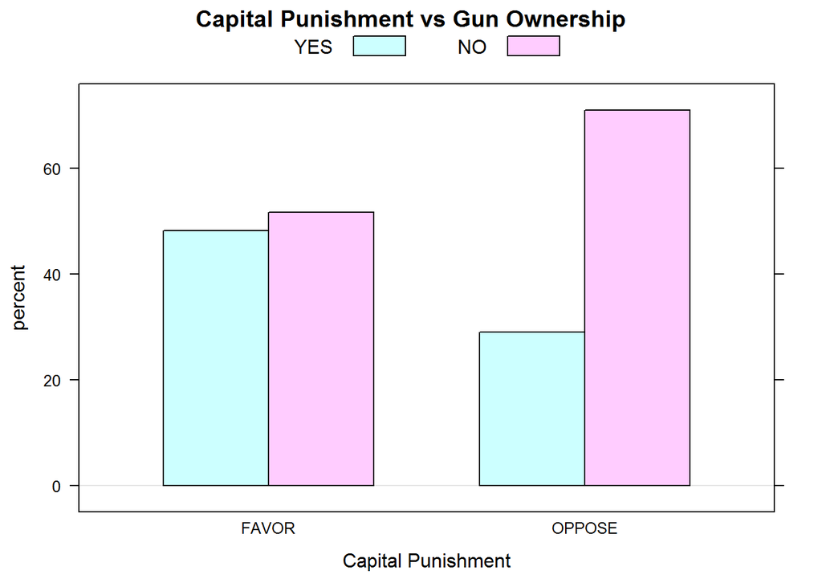

```r
barchartGC(~CAPPUN+OWNGUN, data=mydata4, main='Capital Punishment vs Gun Ownership', type='percent', xlab='Capital Punishment')
```

This barchart shows a relationship between those who favor capital punishment are more likely to own a gun, while those who oppose capital punishment, are less likely to own a gun.

#### 1.2.1.2 Numerical Descriptive Results

```r
tab1 = xtabs(~CAPPUN+OWNGUN, data=mydata4)
rowPerc(tab1)
```

```
##         OWNGUN
## CAPPUN      YES     NO  Total
##   FAVOR   48.28  51.72 100.00
##   OPPOSE  29.03  70.97 100.00
```

This table shows a relationship in which those who favor capital punishment are more likely to own a gun, while those who oppose capital punishment, are less likely to own a gun.

### 1.2.2 Inferential Results

```r
chisqtestGC(tab1)
```

```
## Pearson's Chi-squared test with Yates' continuity correction
##
## Observed Counts:
##         OWNGUN
## CAPPUN   YES NO
##   FAVOR   56 60
##   OPPOSE  18 44
##
## Counts Expected by Null:
##         OWNGUN
## CAPPUN     YES    NO
##   FAVOR  48.22 67.78
##   OPPOSE 25.78 36.22
##
## Contributions to the chi-square statistic:
##         OWNGUN
## CAPPUN    YES   NO
##   FAVOR  1.25 0.89
##   OPPOSE 2.35 1.67
##
##
## Chi-Square Statistic = 5.3932
## Degrees of Freedom of the table = 1
## P-Value = 0.0202
```

The P value for the chisq test is 0.02 < 0.05 so we reject the null hypothesis and conclude we have evidence to support the contention of gun ownership and whether one favors capital punishment are related.

# 2 Introduction Question 2

The second question is this: Is belief in the bigbang theory (BIGBANG) independent of belief in the afterlife (POSTLIFE)?

$H+_0$: There is no relationship between opinion on The Big Bang Theory and belief in the afterlife (POSTLIFE)

$H_A$: There is a relationship between opinion on The Big Bang Theory and belief in the afterlife (POSTLIFE)

## 2.1 Methods

Both variables are categorical; hence we will use a bar graph to graphically show the data, and a cross-tabulation for a numerical summary. A chi-squared test will be used to infer whether or not there is a relationship between the variables

## 2.2 Results

### 2.2.1 Descriptive Results

#### 2.2.1.1 Graphical Descriptive Results

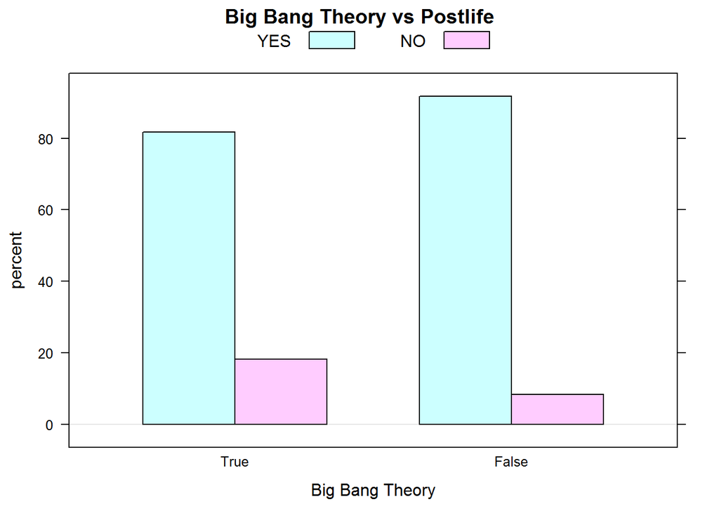

```r
barchartGC(~BIGBANG+POSTLIFE, data=mydata4, main='Big Bang Theory vs Postlife', type='percent', xlab='Big Bang Theory')
```

This barchart shows a relationship between those who favor and oppose the Big Bang Theory also believe in Postlife.

#### 2.2.1.2 Numerical Descriptive Results

```r
tab1 = xtabs(~BIGBANG+POSTLIFE, data=mydata4)
rowPerc(tab1)
```

```
##        POSTLIFE
## BIGBANG    YES     NO  Total
##   True   81.71  18.29 100.00
##   False  91.67   8.33 100.00
```

This table shows a relationship in opinion in which those who favor and oppose The Big Bang Theory also believe in Postlife

### 2.2.2 Inferential Results

```r
chisqtestGC(tab1)
```

```
## Pearson's Chi-squared test with Yates' continuity correction
##
## Observed Counts:
##        POSTLIFE
## BIGBANG YES NO
##   True   67 15
##   False  88  8
##
## Counts Expected by Null:
##        POSTLIFE
## BIGBANG  YES   NO
##   True  71.4 10.6
##   False 83.6 12.4
##
## Contributions to the chi-square statistic:
##        POSTLIFE
## BIGBANG  YES   NO
##   True  0.27 1.83
##   False 0.23 1.56
##
##
## Chi-Square Statistic = 3.0637
## Degrees of Freedom of the table = 1
## P-Value = 0.0801
```